# Homework 08

The former kernel-tuning question has moved to Homework 09.

Solutions for Questions 1 and 2 will be available after Monday, October 19, 2026. No solution can be provided for Question 3.

For Questions 1 and 2, use either R or Python.

## Question 1: Boundary and margin

Use `margin-geometry-20.csv` from the combined ZIP, which contains 20 observations with predictors $x_1,x_2$ and class labels $y\in\{-1,1\}$. Consider the score

$$f(x)=0.8x_1+0.6x_2.$$

Since $\|(0.8,0.6)\|_2=1$, the lines $f(x)=\pm1$ are each a distance 1 from the decision boundary $f(x)=0$.

1. Calculate the distance from every observation to the decision boundary and its functional margin $yf(x)$. In a table, report these values and whether each observation is inside, on, or beyond the margin for its class. Compare $yf(x)$ with 1 to make this distinction.
2. Plot the observations, the boundary $f(x)=0$, and the margin lines $f(x)=\pm1$. Distinguish the two classes and identify the observations inside the margin in your plot.
3. Report how many observations are inside, on, and beyond the margin. Which observations are misclassified by this decision rule?

Use the observation numbers supplied in the data. Set the $x_1$ axis to $[-3.2,3.2]$, set the $x_2$ axis to $[-3,3]$, and use an equal aspect ratio. Do not fit a new classifier for this question.

### Question 1 answer

```python
import numpy as np
import pandas as pd
import matplotlib.pyplot as plt

q1 = pd.read_csv("data/margin-geometry-20.csv")
beta_2d = np.array([0.8, 0.6])
beta_norm_2d = np.linalg.norm(beta_2d)
q1["f(x)"] = beta_2d[0] * q1["x1"] + beta_2d[1] * q1["x2"]
q1["Distance to boundary"] = q1["f(x)"].abs() / beta_norm_2d
q1["Functional margin y*f(x)"] = q1["y"] * q1["f(x)"]
tol = 1e-10
q1["Margin status"] = np.select(
    [q1["Functional margin y*f(x)"] < 1 - tol,
     np.isclose(q1["Functional margin y*f(x)"], 1, atol=tol)],
    ["inside", "on"], default="beyond"
)
display(q1[["observation", "x1", "x2", "y", "f(x)",
            "Distance to boundary", "Functional margin y*f(x)",
            "Margin status"]].style.format({
                "x1": "{:.2f}", "x2": "{:.2f}", "f(x)": "{:.2f}",
                "Distance to boundary": "{:.2f}",
                "Functional margin y*f(x)": "{:.2f}"
            }).hide(axis="index"))
```

| observation | x1 | x2 | y | f(x) | Distance to boundary | Functional margin y*f(x) | Margin status |
| --- | --- | --- | --- | --- | --- | --- | --- |
| 1 | 0.68 | 0.76 | 1 | 1.00 | 1.00 | 1.00 | on |
| 2 | 1.80 | -0.15 | 1 | 1.35 | 1.35 | 1.35 | beyond |
| 3 | 1.38 | 0.66 | 1 | 1.50 | 1.50 | 1.50 | beyond |
| 4 | 0.88 | 1.66 | 1 | 1.70 | 1.70 | 1.70 | beyond |
| 5 | 0.62 | 2.34 | 1 | 1.90 | 1.90 | 1.90 | beyond |
| 6 | 2.78 | -0.04 | 1 | 2.20 | 2.20 | 2.20 | beyond |
| 7 | 1.86 | 1.52 | 1 | 2.40 | 2.40 | 2.40 | beyond |
| 8 | 0.50 | 0.40 | 1 | 0.64 | 0.64 | 0.64 | inside |
| 9 | 0.10 | 0.20 | 1 | 0.20 | 0.20 | 0.20 | inside |
| 10 | -0.40 | 0.20 | 1 | -0.20 | 0.20 | -0.20 | inside |
| 11 | -0.92 | -0.44 | -1 | -1.00 | 1.00 | 1.00 | on |
| 12 | -0.50 | -1.50 | -1 | -1.30 | 1.30 | 1.30 | beyond |
| 13 | -1.90 | -0.05 | -1 | -1.55 | 1.55 | 1.55 | beyond |
| 14 | -0.44 | -2.33 | -1 | -1.75 | 1.75 | 1.75 | beyond |
| 15 | -1.98 | -0.61 | -1 | -1.95 | 1.95 | 1.95 | beyond |
| 16 | -2.74 | 0.07 | -1 | -2.15 | 2.15 | 2.15 | beyond |
| 17 | -1.90 | -1.55 | -1 | -2.45 | 2.45 | 2.45 | beyond |
| 18 | -0.50 | -0.40 | -1 | -0.64 | 0.64 | 0.64 | inside |
| 19 | 0.00 | -0.40 | -1 | -0.24 | 0.24 | 0.24 | inside |
| 20 | 0.40 | -0.20 | -1 | 0.20 | 0.20 | -0.20 | inside |

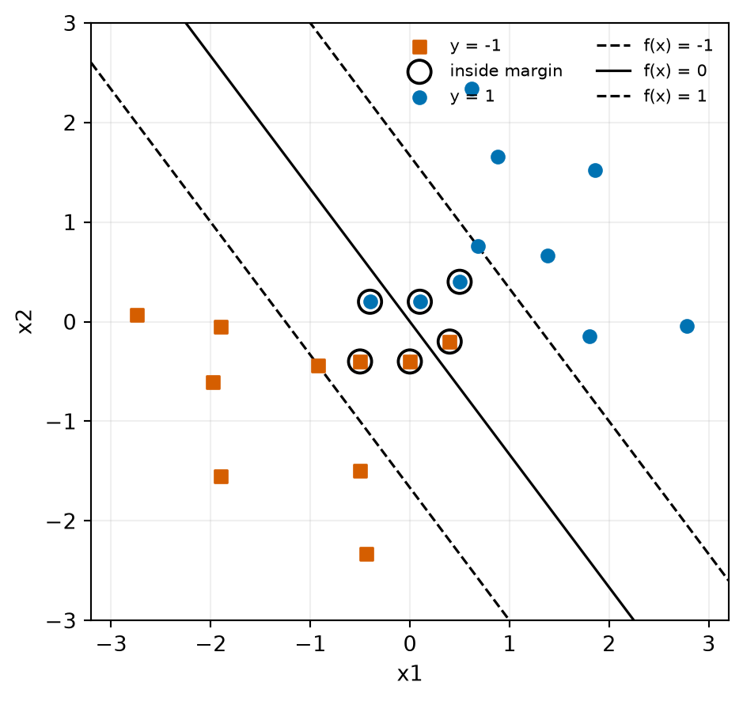

Figure 1: The supplied decision boundary and unit-margin lines.

```python
fig, ax = plt.subplots(figsize=(5.4, 4.5), constrained_layout=True)
colors = {-1: "#D55E00", 1: "#0072B2"}
markers = {-1: "s", 1: "o"}
for label in (-1, 1):
    part = q1[q1["y"] == label]
    ax.scatter(part["x1"], part["x2"], color=colors[label], marker=markers[label],
               label=f"y = {label}", zorder=3)
    inside = part[part["Margin status"] == "inside"]
    ax.scatter(inside["x1"], inside["x2"], facecolors="none", edgecolors="black",
               s=120, linewidths=1.4, label="inside margin" if label == -1 else None,
               zorder=4)
x = np.linspace(-3.2, 3.2, 300)
for c, style, label in [(-1, "--", "f(x) = -1"), (0, "-", "f(x) = 0"),
                         (1, "--", "f(x) = 1")]:
    ax.plot(x, (c - 0.8 * x) / 0.6, style, color="black", linewidth=1.2, label=label)
ax.set(xlim=(-3.2, 3.2), ylim=(-3, 3), xlabel="x1", ylabel="x2")
ax.set_aspect("equal", adjustable="box")
ax.legend(frameon=False, fontsize=8, ncol=2)
ax.grid(alpha=0.2)
plt.show()
```

There are **6 inside**, **2 on**, and **12 beyond** the margin. Observations **10 and 20** are misclassified because their functional margins are negative. In general, (0<y_i f(x_i)<1) means correctly classified but inside the margin, whereas (y_i f(x_i)<0) means the observation is on the wrong side of the decision boundary. Geometrically, the two unit-margin lines are one unit from the boundary because the coefficient norm is one.

## Question 2: Margin in four dimensions

Use `margin-geometry-4d.csv` from the combined ZIP, which contains 50 observations with four predictors and class labels $y\in\{-1,1\}$. Consider the linear score

$$f(\mathbf{x})=\beta_0+\mathbf{x}^{\mathsf T}\boldsymbol{\beta},
\qquad
\beta_0=-1,
\quad
\boldsymbol{\beta}=(1,2,-2,4)^{\mathsf T}.$$

1. Project the observations onto the direction of $\boldsymbol{\beta}$ and plot their positions on one axis. Distinguish the two classes and mark the decision boundary. Use the plot to calculate the geometric margin $M$, the distance from the boundary to the closest observation.
2. Express the same decision boundary using the SVM normalization in which the smallest functional margin $y_i f(\mathbf{x}_i)$ is set to 1. What are the corresponding values of $\boldsymbol{\beta}$ and $\beta_0$?

### Question 2 answer

```python
q2 = pd.read_csv("data/margin-geometry-4d.csv")
beta0 = -1.0
beta = np.array([1.0, 2.0, -2.0, 4.0])
beta_norm = np.linalg.norm(beta)
q2["f(x)"] = beta0 + q2[["x1", "x2", "x3", "x4"]].to_numpy() @ beta
q2["t"] = q2[["x1", "x2", "x3", "x4"]].to_numpy() @ beta / beta_norm
t_boundary = -beta0 / beta_norm
q2["Distance to boundary"] = q2["f(x)"].abs() / beta_norm
q2["|t - t_boundary|"] = (q2["t"] - t_boundary).abs()
q2["Functional margin"] = q2["y"] * q2["f(x)"]
q2_m_min = q2["Functional margin"].min()
beta0_star = beta0 / q2_m_min
beta_star = beta / q2_m_min
normalized_margins = q2["y"] * (beta0_star + q2[["x1", "x2", "x3", "x4"]].to_numpy() @ beta_star)
normalized_scores = beta0_star + q2[["x1", "x2", "x3", "x4"]].to_numpy() @ beta_star
boundary_check = np.max(np.abs(normalized_scores - q2["f(x)"].to_numpy() / q2_m_min))
print(f"||beta|| = {beta_norm:.4f}; t_boundary = {t_boundary:.4f}")
print(f"geometric margin M = {q2['Distance to boundary'].min():.4f}")
print(f"minimum original functional margin = {q2_m_min:.4f}")
print(f"minimum normalized functional margin = {normalized_margins.min():.4f}")
print(f"normalized boundary check = {boundary_check:.2e}")
display(q2[["observation", "y", "f(x)", "t", "Distance to boundary",
            "|t - t_boundary|", "Functional margin"]].style.format({
                "f(x)": "{:.4f}", "t": "{:.4f}",
                "Distance to boundary": "{:.4f}",
                "|t - t_boundary|": "{:.4f}",
                "Functional margin": "{:.4f}"
            }).hide(axis="index"))
```

```
||beta|| = 5.0000; t_boundary = 0.2000
geometric margin M = 1.0000
minimum original functional margin = 5.0000
minimum normalized functional margin = 1.0000
normalized boundary check = 8.88e-16
```

| observation | y | f(x) | t | Distance to boundary | \|t - t_boundary\| | Functional margin |
| --- | --- | --- | --- | --- | --- | --- |
| 1 | -1 | -8.0000 | -1.4000 | 1.6000 | 1.6000 | 8.0000 |
| 2 | 1 | 10.0000 | 2.2000 | 2.0000 | 2.0000 | 10.0000 |
| 3 | -1 | -10.5000 | -1.9000 | 2.1000 | 2.1000 | 10.5000 |
| 4 | 1 | 5.0000 | 1.2000 | 1.0000 | 1.0000 | 5.0000 |
| 5 | -1 | -8.0000 | -1.4000 | 1.6000 | 1.6000 | 8.0000 |
| 6 | -1 | -6.5000 | -1.1000 | 1.3000 | 1.3000 | 6.5000 |
| 7 | -1 | -7.5000 | -1.3000 | 1.5000 | 1.5000 | 7.5000 |
| 8 | -1 | -7.0000 | -1.2000 | 1.4000 | 1.4000 | 7.0000 |
| 9 | -1 | -9.5000 | -1.7000 | 1.9000 | 1.9000 | 9.5000 |
| 10 | 1 | 7.5000 | 1.7000 | 1.5000 | 1.5000 | 7.5000 |
| 11 | -1 | -9.0000 | -1.6000 | 1.8000 | 1.8000 | 9.0000 |
| 12 | 1 | 7.0000 | 1.6000 | 1.4000 | 1.4000 | 7.0000 |
| 13 | 1 | 11.5000 | 2.5000 | 2.3000 | 2.3000 | 11.5000 |
| 14 | 1 | 7.0000 | 1.6000 | 1.4000 | 1.4000 | 7.0000 |
| 15 | -1 | -5.0000 | -0.8000 | 1.0000 | 1.0000 | 5.0000 |
| 16 | 1 | 8.5000 | 1.9000 | 1.7000 | 1.7000 | 8.5000 |
| 17 | -1 | -6.0000 | -1.0000 | 1.2000 | 1.2000 | 6.0000 |
| 18 | 1 | 11.0000 | 2.4000 | 2.2000 | 2.2000 | 11.0000 |
| 19 | 1 | 11.0000 | 2.4000 | 2.2000 | 2.2000 | 11.0000 |
| 20 | -1 | -8.5000 | -1.5000 | 1.7000 | 1.7000 | 8.5000 |
| 21 | -1 | -7.0000 | -1.2000 | 1.4000 | 1.4000 | 7.0000 |
| 22 | -1 | -9.0000 | -1.6000 | 1.8000 | 1.8000 | 9.0000 |
| 23 | -1 | -11.0000 | -2.0000 | 2.2000 | 2.2000 | 11.0000 |
| 24 | 1 | 10.0000 | 2.2000 | 2.0000 | 2.0000 | 10.0000 |
| 25 | -1 | -10.0000 | -1.8000 | 2.0000 | 2.0000 | 10.0000 |
| 26 | -1 | -12.0000 | -2.2000 | 2.4000 | 2.4000 | 12.0000 |
| 27 | -1 | -7.5000 | -1.3000 | 1.5000 | 1.5000 | 7.5000 |
| 28 | 1 | 8.0000 | 1.8000 | 1.6000 | 1.6000 | 8.0000 |
| 29 | -1 | -9.5000 | -1.7000 | 1.9000 | 1.9000 | 9.5000 |
| 30 | 1 | 8.5000 | 1.9000 | 1.7000 | 1.7000 | 8.5000 |
| 31 | 1 | 6.0000 | 1.4000 | 1.2000 | 1.2000 | 6.0000 |
| 32 | 1 | 10.5000 | 2.3000 | 2.1000 | 2.1000 | 10.5000 |
| 33 | 1 | 5.0000 | 1.2000 | 1.0000 | 1.0000 | 5.0000 |
| 34 | -1 | -8.5000 | -1.5000 | 1.7000 | 1.7000 | 8.5000 |
| 35 | 1 | 8.0000 | 1.8000 | 1.6000 | 1.6000 | 8.0000 |
| 36 | -1 | -5.0000 | -0.8000 | 1.0000 | 1.0000 | 5.0000 |
| 37 | 1 | 12.0000 | 2.6000 | 2.4000 | 2.4000 | 12.0000 |
| 38 | 1 | 10.5000 | 2.3000 | 2.1000 | 2.1000 | 10.5000 |
| 39 | 1 | 6.5000 | 1.5000 | 1.3000 | 1.3000 | 6.5000 |
| 40 | -1 | -10.0000 | -1.8000 | 2.0000 | 2.0000 | 10.0000 |
| 41 | 1 | 6.5000 | 1.5000 | 1.3000 | 1.3000 | 6.5000 |
| 42 | 1 | 9.5000 | 2.1000 | 1.9000 | 1.9000 | 9.5000 |
| 43 | 1 | 9.0000 | 2.0000 | 1.8000 | 1.8000 | 9.0000 |
| 44 | -1 | -6.5000 | -1.1000 | 1.3000 | 1.3000 | 6.5000 |
| 45 | -1 | -11.0000 | -2.0000 | 2.2000 | 2.2000 | 11.0000 |
| 46 | -1 | -10.5000 | -1.9000 | 2.1000 | 2.1000 | 10.5000 |
| 47 | 1 | 9.0000 | 2.0000 | 1.8000 | 1.8000 | 9.0000 |
| 48 | 1 | 9.5000 | 2.1000 | 1.9000 | 1.9000 | 9.5000 |
| 49 | -1 | -11.5000 | -2.1000 | 2.3000 | 2.3000 | 11.5000 |
| 50 | 1 | 7.5000 | 1.7000 | 1.5000 | 1.5000 | 7.5000 |

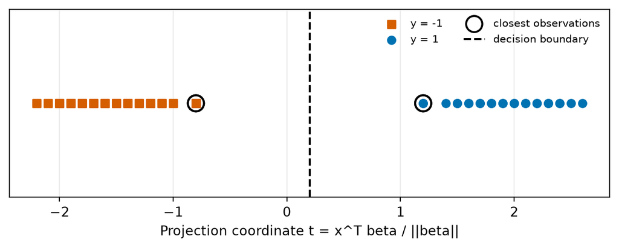

Figure 2: Four-dimensional observations projected onto the beta direction.

```python
fig, ax = plt.subplots(figsize=(6.4, 2.5), constrained_layout=True)
for label, color, marker in [(-1, "#D55E00", "s"), (1, "#0072B2", "o")]:
    part = q2[q2["y"] == label]
    ax.scatter(part["t"], np.zeros(len(part)), color=color, marker=marker,
               label=f"y = {label}", zorder=3)
closest = q2[np.isclose(q2["Distance to boundary"], q2["Distance to boundary"].min())]
ax.scatter(closest["t"], np.zeros(len(closest)), facecolors="none", edgecolors="black",
           s=150, linewidths=1.5, label="closest observations", zorder=4)
ax.axvline(t_boundary, color="black", linestyle="--", label="decision boundary")
ax.set(yticks=[], xlabel="Projection coordinate t = x^T beta / ||beta||")
ax.grid(axis="x", alpha=0.25)
ax.legend(frameon=False, ncol=2, fontsize=8)
plt.show()
```

## Question 3: Peer review of a Homework 7 skill

Peer review Issue: [Peer review of Homework 7 skill](https://github.com/manntalati/stat432-fall2026/issues/4)

The instructor’s GitHub account, **rqzhu-aide**, will open a **GitHub Issue** in the repository containing your Homework 7 submission. It will link to **one** assigned student’s repository.

1. **Use the skill.** Find the complete skill definition in the assigned student’s Homework 7 report. Copy it without changes into a local `SKILL.md` file in your own folder. You do not need to install it. Give your agent the path to the file and explicitly ask it to follow that skill while analyzing the `SAheart` data, using the response and predictor coding from Homework 7. Provide the necessary data information, but no additional preferences about methods, figures, model selection, or report style. Let the skill direct the analysis.

   Monitor the time, your token use, and your weekly quota while the agent works. If the run is taking too long or using your allowance too quickly, you may send a **steer message** asking the agent to finish immediately, or stop the run and summarize what you observed. A steer message redirects an agent while it is working; learn how to send one in your AI tool before starting.
2. **Write a peer review.** Read the student’s submitted report and what the skill produced in your run. Give a brief overall assessment, followed by **three major items the author could improve**. You may comment on any aspect of the skill or report. For each item, explain what you observed, why it matters, and what you recommend changing. If you stopped the run early, explain where and why. Write the review yourself, without AI assistance.
3. **Share your review.** Open a GitHub Issue in the assigned student’s Homework 7 repository containing your review. Copy the same review into your Homework 8 submission report and include a link to the GitHub Issue.

### Question 3 answer

> **Overall assessment**

> The skill produced a clear, reproducible, and statistically sound LDA/QDA workflow. In my review run, it preserved a held-out test set, reused the same stratified cross-validation folds across the candidate configurations, fitted scaling and PCA within each training fold, and evaluated the test set only after model selection. The run reproduced the reported behavior: PCA + LDA with seven components had the lowest CV error, while the one-standard-error rule selected ordinary LDA. I did not observe an execution failure. The main opportunities for improvement are small ambiguities that could matter when the skill is reused on datasets other than SAheart.

> **1. Clarify the one-standard-error rule.**

> The skill says to choose among candidates “within one standard error” of the minimum-error model, but it does not explicitly state which standard error defines that threshold. In my run, I used the standard error of the minimum-CV-error candidate. This gave a threshold of approximately 0.2786 and selected ordinary LDA. That interpretation is conventional, but another agent could interpret the instruction differently. I recommend stating explicitly that the threshold is the minimum mean CV error plus the standard error of the minimum-error candidate, followed by a deterministic tie-breaking rule.

> **2. Specify the positive or class-of-interest label.**

> The skill requires sensitivity and specificity for the “class of interest,” but the required inputs do not specify which response level should be treated as that class. This was unambiguous for SAheart because `chd=1` naturally represents CHD, but the skill is intended to be reusable. For another binary outcome, different agents could choose different positive classes and report different sensitivity and specificity values. I recommend adding the class of interest to the required user inputs or defining a deterministic default.

> **3. Define how missing predictor values should be handled.**

> The skill asks the agent to report missing values and specifies what to do when the response is missing, but it does not state how missing predictor values should be handled. This did not affect the SAheart run because no predictor values were missing. For another dataset, an agent might drop observations, impute values, or fail; preprocessing performed before cross-validation could also create data leakage. I recommend specifying either that the agent should stop and ask the user when predictor values are missing, or that imputation must be performed separately within each cross-validation training fold.